# Research Method of Data Science

## Week 13: Beyond the Baseline and Text as Data

### Iegor Vyshnevskyi, Ph.D.

### Sogang University

### November 24/26, 2026

# Agenda

**Tuesday — Meeting 1**

1. Causal reasoning beyond the regression baseline

2. Prediction versus explanation

3. Turning real texts into research measures

4. Sentiment, classification and LLM labeling

5. AI verification and Thursday preparation

Appendix: tools, extensions, references and reporting.

# Last week’s model leaves new questions

An adjusted regression can describe a conditional association.

A strong prediction score can show success on a defined evaluation task.

Today we ask:

- What would justify a causal claim?

- How can a sentence become a research variable?

- How do we verify AI-assisted evidence?

**Three separate decisions:** what we may claim, how we turn evidence into a measure, and how we check the result.

# A useful output needs a clear claim

**Quick individual choice — 1 minute**

Which claim is closest to your current project?

**Description · adjusted association · causal explanation · prediction · qualitative understanding**

Keep your choice visible. You will revisit it on Thursday.

Your claim determines the evidence you need. A prediction claim needs new-case performance; a causal claim needs a design that supports a counterfactual comparison.

# 1. Causal reasoning beyond the baseline

# A causal question needs a counterfactual

For the same unit, what would the outcome have been **with** the intervention and **without** it?

We observe only one of those outcomes for that unit.

A comparison group helps only when the design makes its outcomes informative about the missing counterfactual.

More controls or a more flexible model cannot supply that argument by themselves.

**Example:** for one student, we want the test score with an AI tutor and the score the same student would have had without it. We can observe only one, so the design must supply a credible comparison.

> Counterfactual  is a hypothetical "what-if" scenario that estimates what would have happened to an economic variable or outcome if a specific policy, event, or intervention had not occurred—or had occurred differently. Because the true counterfactual is never directly observed alongside actual reality, economists use data, experiments, and models to approximate it.

# Real evidence: training and earnings

**Research question:** Does participation in a job-training program increase later earnings?

The historical NSW records compare **185 people assigned to training** with **260 experimental controls**. Earnings are observed before the program in 1975 and after it in 1978.

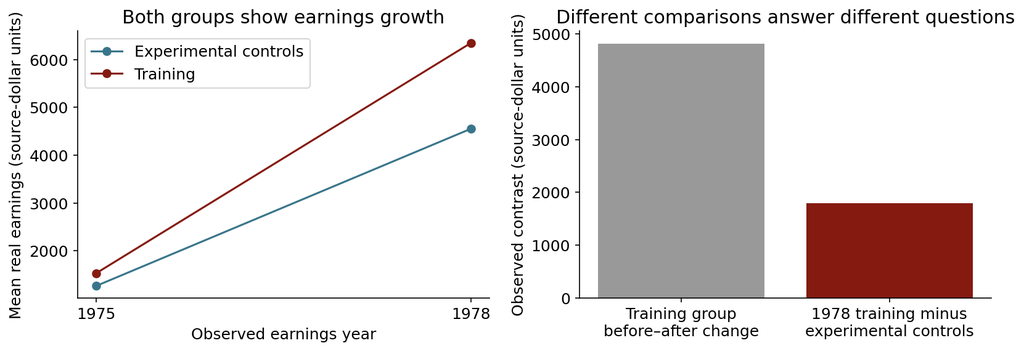

### Left: change over time

Earnings increased in both groups. The training group increased more, so its before-after change alone includes improvement that also occurred without training.

### Right: two different contrasts

The training group rose by about **$4,817**. In 1978 it earned about **$1,794 more** than the experimental control group. These answer different questions.

**Interpretation:** the assigned-group comparison is more informative about the training effect than the trainees’ before-after change. Historical subset reconstruction and generalizability still limit the claim.

# A possible confounder changes the argument

**Practical example:** students with weaker prior preparation may rely more heavily on AI tools. The same weaker preparation may also lead to lower critical-thinking scores.

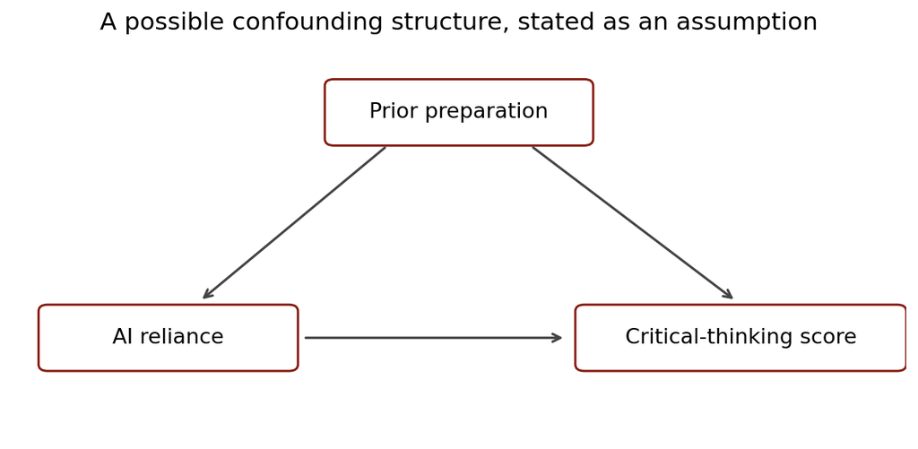

### Observed association

Students with higher AI reliance have lower critical-thinking scores.

### Alternative explanation

Prior preparation influences both variables. The association may therefore exist even if AI use has no causal effect.

A **confounder** is a prior factor related to both the proposed cause and the outcome. The diagram states a possible causal structure that the researcher must justify with theory and evidence.

# Design choices address different threats

Each design creates a different comparison. Its credibility depends on a specific assumption.

DesignPractical exampleWhat must be credible

**Random assignment**Randomly offer an AI tutor, then compare later unaided test scoresAssignment was followed; attrition and spillovers did not destroy comparability

**Difference-in-differences**Compare score changes before and after an AI policy at one school and a similar schoolWithout the policy, the two schools would have followed parallel trends

**Regression discontinuity**Compare students just above and below an 80-point eligibility cutoffNear the cutoff, students are comparable and cannot precisely manipulate the score

**Instrumental variables**Use distance to a training center as a source of variation in program participationDistance changes participation but has no other pathway to the outcome

**Method names are not proof.** Researchers must explain why the assignment rule, timing or instrument supports the intended causal comparison.

# Claim repair — pairs, 3 minutes

A researcher finds that frequent AI users have lower critical-thinking scores in one survey.

They write: **“AI use reduces critical thinking.”**

1. Name one alternative explanation.

2. Rewrite the claim to fit the evidence.

3. Name one design improvement and its remaining limitation.

**Deliverable:** one defensible sentence describing the current evidence, plus one design change that would support a stronger claim.

# 2. Prediction versus explanation

# The aim determines what counts as success

Before choosing software, decide what kind of statement the study should support. The same dataset can serve different aims, but each aim requires different evidence.

| Aim | Question | Evidence to report |
|---|---|---|
| Description | What is present in these records? | Defined measures and sample boundaries |
| Adjusted association | How do recorded variables relate? | Specification, contrast and uncertainty |
| Causal explanation | What changes under an intervention? | Identification argument and estimation |
| Prediction | How well can we predict new outcomes? | New-case performance and a baseline |

**One news corpus, four aims:** count risk mentions; relate mentions to firm characteristics; estimate the effect of a disclosure rule; or predict a human label for a new sentence.

# A prediction exercise needs a deployment target

A **deployment target** describes the cases the model will face after development. What will be “new” when the model is used?

- New sentences from a similar corpus?
- A later time period?
- A new firm, country, language or source?

The evaluation split should reflect that target.

A random split can put related articles or templates in both training and test sets. The model may then appear accurate because it has already seen nearly identical language.

**Example:** if the model will label next year’s news, evaluate it on a later time period rather than a random sample from the same dates.

**Practical rule:** the test data should resemble what will truly be new when the model is used.

# Text classification has a different target

Thursday’s classifier predicts a **human sentiment label**.

A correct label shows agreement with that annotation task.

It does not establish:

- a change in stock prices
- the writer’s private beliefs
- a causal mechanism
- performance on texts the model may already have seen during pretraining

A classifier can reproduce a coding rule accurately even when that rule is an imperfect measure of the broader concept.

# Method choice — pairs, 2 minutes

Choose the main evidence needed for each question:

1. How often do these news sentences mention earnings?

2. Can a model label a new sentence correctly?

3. Does a central bank announcement change market prices?

For each, name one claim that the proposed data would not yet support.

First identify the intended claim. Then choose the evidence and evaluation that match it.

# 3. Turning real texts into research measures

# Text as data: language becomes systematic evidence

News, speeches, interviews, reports and open-ended survey answers contain evidence that may not exist in ordinary numerical variables. Text analysis helps researchers **describe patterns, compare groups, retrieve evidence and predict labels at scale**.

**One sentence through several approaches:** “Profit before taxes decreased to EUR 31.6 mn from EUR 50.0 mn.”

**Read and code**Keep the full sentence and contextA human applies a codebook and records supporting evidence

**Bag of words**Count tokens such as *profit* and *decreased*Transparent frequencies, but word order and context are mostly lost

**TF-IDF + classifier**Upweight terms that distinguish documents or labelsA linear model learns which weighted terms predict a label

**VADER or lexicon**Apply predefined word scores and rulesFast and interpretable, but the domain may not match finance

**BERT / RoBERTa**Represent each word using its surrounding contextFine-tune contextual representations for classification or retrieval

**LLM or human codebook**Apply written instructions to the complete passageReturn categories and evidence, followed by human validation

**Start before the algorithm:** define the research question, construct, unit of text, source and validation plan. A more complex model does not automatically produce a better measure.

# The unit comes before the algorithm

A **document** is the text unit stored in one row for analysis. It might be a sentence, interview, speech, article or report.

**Example:** to study how presidents frame economic risk, one speech may be the research unit even when software processes it sentence by sentence.

Choose and record:

- what enters the corpus and what is excluded
- the unit and its stable ID
- source, language and available metadata
- the construct you want to measure

A hundred sentences from one speech are not a hundred independent speeches.

The same source can produce different datasets: one row per sentence, article, speaker or interview. The unit determines what N means.

# Our real corpus: Financial PhraseBank

**Published financial-news sentences with human labels.** Annotators judged whether each sentence was negative, neutral or positive from an investor’s perspective. The label describes the sentence, not the company’s later stock return.

| Stage | N |
|---|---:|
| Original AllAgree subset | 2,264 |
| After 5 exact normalized duplicate removals | 2,259 |
| Training / test sentences | 1,694 / 565 |

Investor-perspective labels: **negative, neutral, positive**. The training set teaches the classifier; the test set stays separate until the final assessment.

Malo and colleagues. Data: **CC BY-NC-SA 3.0**, for this noncommercial class.

AllAgree is the easiest subset because every annotator agreed. Strong results here may not transfer to ambiguous financial language.

# Text representations serve different aims

One sentence can become several kinds of data. For *profit decreased*, counts retain the words, TF-IDF changes their weights, a sentiment model assigns polarity, and an embedding represents similarity to other texts.

| Representation | What it offers | What to check |
|---|---|---|
| Word counts | Transparent frequency measure | Corpus size, tokenization and boilerplate |
| TF-IDF | Weighted distinctive terms | Training vocabulary and preprocessing |
| Sentiment score | A defined polarity measure | Domain and construct fit |
| Human or LLM codes | Contextual categories | Codebook, agreement and errors |
| Embeddings | Similarity and retrieval | Whether similarity serves the task |

Measurement choices need validation.

A representation is a measurement decision: it decides which features of language the analysis keeps and which it ignores.

# BERT and RoBERTa read words in context

**Example:** “Operating profit **[MASK]** by 12%.” The words on both sides help the model decide whether the missing word is *rose* or *fell*.

**Contextual representation** means that the model can represent the same word differently when its surrounding sentence changes. This helps with words whose meaning depends on context.

| Model | How it learns general language patterns | How researchers use it |
|---|---|---|
| **BERT** | Hides some words during pretraining and learns to predict them from left and right context | Add a small task layer, then fine-tune on labeled examples |
| **RoBERTa** | Keeps BERT’s encoder idea but trains longer, on more data, with dynamic masking and without the next-sentence task | Use the same fine-tuning approach, then validate on the target corpus |

For sentiment classification, the complete sentence becomes a contextual representation and the task layer predicts **negative, neutral or positive**.

**Pretrained** means the model learned broad language patterns before our study. **Fine-tuned** means we adapt it using labeled examples for one specific task.

# A readable first look at real texts

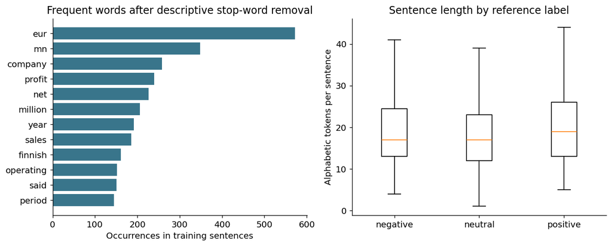

### Frequent terms

*eur*, *mn*, company and profit appear often. This tells us what the corpus discusses, but common words may provide little help in separating labels.

### Sentence length

The three boxplots overlap strongly. Positive sentences are somewhat longer in the middle of the distribution, but length alone cannot identify sentiment.

This is exploratory description. It helps detect unusual text and corpus structure before modelling; it does not explain why annotators chose a label.

# TF-IDF makes comparisons more selective

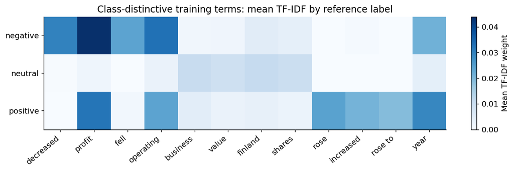

### How to read the colour

A darker cell means that a term has a higher average TF-IDF weight for sentences with that reference label.

### What the pattern suggests

*decreased* is more distinctive for negative sentences, while *rose* and *increased* are more distinctive for positive sentences. Profit appears across labels, so context still matters.

TF-IDF highlights potentially useful differences in word use. It does not understand negation, numbers or meaning by itself, and this chart does not establish causal relationships.

# Human coding challenge — pairs, 5 minutes

**Three real Financial PhraseBank sentences:**

A. “International sales rose by 59.8 % to EUR 1,244.4 mn .”

B. “Profit before taxes decreased to EUR 31.6 mn from EUR 50.0 mn the year before .”

C. “The divested activities had net sales of EUR 145.1 million in 2009 and an operating profit of EUR 8.9 million .”

Choose an investor-perspective label. Underline the evidence and identify any ambiguity.

Record the label, the exact words or numbers that support it, and any uncertainty. A label without evidence is difficult to audit.

# 4. Sentiment, classification and LLM labeling

# A sentiment score needs an interpretation

**VADER** combines a word lexicon with rules for negation, capitalization and punctuation.

Its **compound score** summarizes the rule-based polarity judgement on a scale from **−1 to +1**. Scores near −1 are more negative, scores near +1 are more positive, and scores near zero are treated as neutral under the chosen cutoff.

We classify scores using fixed cutoffs:

**≤ −0.05: negative · between: neutral · ≥ +0.05: positive**

**Example:** a score of +0.44 becomes positive under the ±0.05 rule. The score measures the model’s polarity judgement; +0.44 does not mean a 44% probability of a positive return.

VADER is a rule-based measurement tool created for general social-media language. Finance-specific validation is necessary before treating its score as investor sentiment.

# Real sentences expose a domain mismatch

| Sentence | Human reference | VADER compound / label |
|---|---|---|
| International sales rose by 59.8% ... | Positive | 0.000 / Neutral |
| Profit before taxes decreased to EUR 31.6 mn ... | Negative | +0.440 / Positive |

The original full sentences appear in the notebook and source file.

A financial comparison can depend on **direction and numbers**, even when familiar sentiment words point elsewhere.

The error comes from construct mismatch: generic positive words can conflict with the direction of a financial change.

# A threshold can change the measured pattern

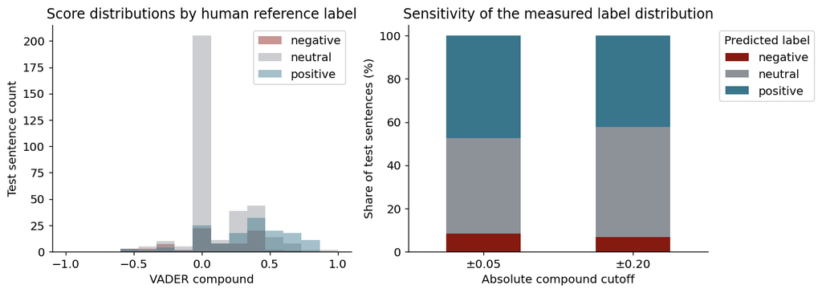

### Left: score overlap

Human negative, neutral and positive sentences receive overlapping VADER scores. Many neutral sentences sit exactly at zero, but some negative sentences receive positive scores.

### Right: cutoff sensitivity

Widening the neutral band from ±0.05 to ±0.20 moves more sentences into the neutral category. The texts stay unchanged; only the decision rule changes.

A threshold is part of the measurement definition. Report it, justify it and check whether a reasonable alternative changes the substantive conclusion.

# Evaluation should include a baseline

| Method | Accuracy | Macro-F1 |
|---|---|---|
| Majority baseline | 0.614 | 0.254 |
| VADER ±0.05 | 0.581 | 0.486 |
| VADER ±0.20 | 0.589 | 0.481 |
| TF-IDF + logistic | 0.874 | 0.836 |

**565 held-out sentences.** Settings fixed before assessment.

Accuracy: share correctly labeled. Macro-F1: equal weight to each class.

High neutral prevalence makes the majority baseline look deceptively competitive on accuracy. It receives 61.4% accuracy by always choosing the largest class, yet its 0.254 Macro-F1 shows poor performance across the three labels.

**Conclusion:** TF-IDF plus logistic regression performs best here: 87.4% accuracy and 0.836 Macro-F1 on the untouched test sentences.

A useful model must improve on a simple alternative. Macro-F1 matters here because it gives negative, neutral and positive classes equal importance.

# The confusion matrix locates the errors

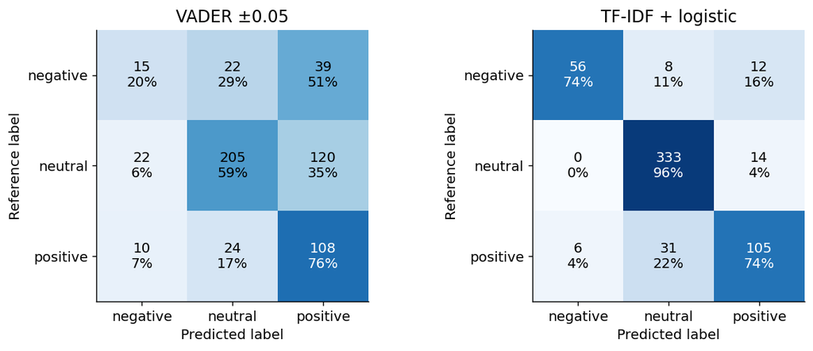

### VADER example

Among 76 human-negative sentences, VADER labels only 15 correctly and calls 39 positive. The generic lexicon often misses financial direction.

### TF-IDF example

The trained classifier correctly labels 56 of the 76 negative sentences. It improves substantially, but 20 negative sentences still enter the wrong column.

Read one row at a time: start with the human reference label, then follow the row across predicted labels. Diagonal cells are correct; off-diagonal cells are errors worth inspecting.

# An LLM can apply an explicit codebook

A **codebook** gives written definitions, allowed labels and decision rules. An LLM can apply those instructions to a small batch of **IDs and texts**, without seeing the human reference labels.

Require:

- one label per ID, including **unclear** when warranted
- a short exact evidence quote
- valid structured output

Record the model, provider, prompt, timestamp and checks. Then compare a sample with human coding. A fluent explanation from the model can still quote the wrong words or apply the codebook inconsistently.

A codebook makes the task clearer, but the model can still misunderstand a sentence, omit an ID or return invalid output. Human checking remains part of the method.

# 5. AI verification and Thursday preparation

# OpenRouter is a gateway to hosted models

OpenRouter is **not one AI model**. It acts as a routing service between the notebook and hosted models from different providers. The notebook sends one request format; OpenRouter forwards it to the selected model and returns the response.

| Step | What happens | Why it matters |
|---|---|---|
| **1. Prepare** | The notebook sends IDs, unchanged text, allowed labels and the codebook | Every model receives the same task |
| **2. Route** | OpenRouter contacts a named model or selects a free model | A named model is easier to reproduce |
| **3. Return** | The model supplies labels and exact evidence quotes in JSON | Structured fields are easier to check |
| **4. Validate** | The notebook checks IDs, labels, quotes and missing items | Invalid output does not enter the analysis |

Keep the API key in an environment variable or Colab Secret. Record the actual returned model because free routing and model availability can change.

# One OpenRouter labeling request

## What the notebook sends

```
model: "openrouter/free"
task: "Label investor sentiment"
allowed: [negative, neutral, positive, unclear]
```

# Four checks make an AI-assisted result reviewable

| Check | Concrete action |
|---|---|
| Code | Test IDs, denominators, score ranges and separation |
| Claim | Compare the wording with the actual evidence |
| Citation | Locate the original and check claim support |
| Sensitivity | Vary a justified threshold, prompt or specification |

**Practical example:** when an AI labels a sentence negative, code checks confirm the ID and allowed label; claim checks inspect the quoted words; citation checks return to the original sentence; sensitivity checks compare a justified prompt or threshold.

Keep disagreements, abstentions and failures visible.

Passing code checks does not validate the research design.

Verification should use evidence outside the AI response whenever possible: original data, executable checks and the cited source.

# Thursday protects your own research time

**First 40 minutes:** guided text and verification notebook.

**Next 35 minutes:** your individual project.

Bring your current question, literature review, data and code.

Your goal is one improved research output, a verification record, and a clear next step for the complete paper.

You may use a quantitative, qualitative or text approach when it fits your question.

The guided notebook teaches one workflow. The studio applies the same logic to each student’s actual question and evidence.

# Thursday: Method choice and AI verification

# Agenda

**Thursday — Meeting 2**

**Guided notebook: 40 minutes maximum**

1. Source and text measures

2. Sentiment and classification

3. Manual/LLM audit and verification

**Individual project studio: 35 minutes**

4. Apply a justified method to your own evidence

5. Check one output, exchange feedback, and save progress

# 0. Setup and source — 4 minutes

Open **W13_RMDS_Text_and_Verification_Lab.ipynb**.

Save a personal copy. Run notebook **0**.

Check the unit, source, label definitions and sample flow.

**Expected:** 2,264 raw sentences, 5 normalized duplicate removals, then 1,694 training and 565 test sentences.

Before modelling, confirm what one row represents, where the labels came from and which records enter training and test sets.

# 1. Text measures — 6 minutes

Run notebook **1**.

Read the frequent-term chart, sentence lengths and TF-IDF heatmap.

**Write two sentences:**

- One observable pattern is ...
- That pattern alone does not establish ...

Explain why a word such as **profit** can occur under different labels.

Description comes first: inspect the texts before interpreting any automated score or classifier.

# 2. Sentiment sensitivity — 6 minutes

Run notebook **2**.

Compare VADER scores and the two fixed cutoff rules.

Record how many labels change and how the neutral share changes.

**Explain:** Is this a different measurement rule, a real-world change, or evidence of a causal effect?

The goal is not to find the cutoff you like best. It is to show whether a reasonable measurement choice changes the conclusion.

# 3. Classification and errors — 8 minutes

Run notebook **3**.

Read the baseline and model metrics, then one off-diagonal confusion-matrix cell.

Inspect one real error sentence.

**Write:** which words support your interpretation, and what the evaluation does not establish.

A model score summarizes many decisions. Inspecting a real error reveals which language the summary hides.

# 4. Six-sentence audit — 8 minutes

Run notebook **4**.

**First:** assign your own labels and evidence quotes.

**Then:** compare with the human reference and local methods.

If the instructor enables live OpenRouter calls, inspect labels and compare the two prompt versions.

If a call fails, use the manual route and move on.

Make your own judgement before viewing the reference or model output. This prevents the model’s answer from anchoring your reading.

# 5. Verification and saving — 8 minutes

Run notebook **5**.

Repair one unsupported claim. Check its citation against the original source.

Record one sensitivity result and one unresolved limitation.

Save the output ZIP and your edited notebook separately.

**At minute 40, stop the guided notebook.**

Save the evidence needed to reconstruct your conclusion, not only the final number or chart.

# Your individual research project: 35 minutes

# Minutes 40–45: method choice

Write four lines for your own study:

1. My research question is ...

2. My unit and source are ...

3. My intended claim is ...

4. My method fits because ...

Use the literature and your available evidence. Revise an overambitious claim if necessary.

The four lines should form one coherent chain: question, unit, claim and method must refer to the same study.

# Minutes 45–60: one useful project output

Work individually on **one** concrete improvement:

- a clean table or figure with a clear denominator

- a defensible regression or prediction result

- a documented text measure or coding result

- a theme supported by qualitative evidence

Write a short interpretation for the Results section. I will circulate for brief consultations.

One well-explained result is more useful than several unfinished analyses.

# Minutes 60–68: verify your own evidence

Check your own work:

**Code/data:** one transformation, join, unit or denominator.

**Claim/citation:** one substantive sentence against its actual source.

**Sensitivity:** one justified alternative definition, specification or coding choice.

Record what changed, what stayed similar, and what remains uncertain.

Choose a check that could realistically reveal a weakness in your current conclusion.

# Minutes 68–73: structured peer check

In pairs, give each researcher about **2 minutes**, then agree on next steps.

Ask:

- Does this output answer the stated question?
- Is the claim stronger than the design allows?
- Can I trace the result to data, code or excerpts?
- What should be clarified in the paper?

Give one specific revision the researcher can complete, rather than a general judgement such as ‘looks good.’

# Minutes 73–75: save a research progress note

Save together:

- question and chosen method
- one output with interpretation
- checks performed and their results
- one limitation
- the next concrete action

Use this record in **Data, Methods and Results**. Week 14 connects the complete paper draft.

This note becomes a bridge from today’s analysis to the written Methods, Results and Limitations sections.

# Appendix: tools, extensions and reporting

# The OpenRouter demo is a bounded experiment

- Named free model, checked against the live catalog
- Six public source sentences, without reference labels
- One batch per prompt, at most two prompts
- Zero price caps and no paid fallbacks
- Required IDs, allowed labels and exact quotes
- Safe cache with model, prompt, time and hashes

Do not distribute the instructor’s key or send private interviews to a hosted model.

The small audit demonstrates a reproducible workflow. Six selected sentences cannot establish general model accuracy.

# Named free models and reproducibility

Catalog examples checked on **20 November 2026**:

- `google/gemma-4-26b-a4b-it:free`
- `nvidia/nemotron-3.5-lightning:free`
- `liquid/lfm-3-1.7b:free`

`openrouter/free` selects among currently available free models that fit the request.

Recheck availability and record the actual returned model. A free endpoint can still be rate-limited or unavailable.

A named model improves traceability. The free router improves convenience but may send different requests to different models.

# Similarity is another text application

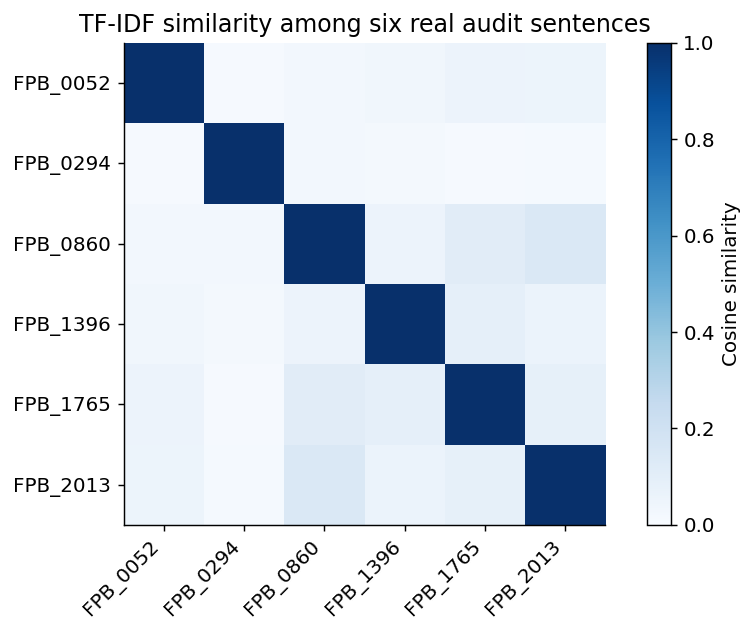

### How to read the matrix

The diagonal equals 1 because every sentence is identical to itself. Darker off-diagonal cells indicate pairs that share more heavily weighted terms.

### What similarity means

Two sentences can use similar vocabulary while expressing different sentiment or describing different events. Researchers must inspect the actual pair.

Cosine similarity measures closeness in the chosen TF-IDF representation. It does not by itself establish a shared argument, cause or substantive meaning.

# Other software extends the workflow

| Task | Tool examples |
|---|---|
| Counts, TF-IDF and classification | pandas and scikit-learn |
| Lexicon/rule sentiment | VADER |
| Tokenization and named entities | spaCy |
| Domain models and embeddings | Hugging Face / FinBERT / sentence embeddings |
| Hosted LLM coding | OpenRouter plus validated structured output |
| Original-source and reference checks | Publisher/preprint pages and Zotero |

Choose tools after defining the research task.

Choose software only after defining the task. A more advanced model does not repair a weak construct or evaluation design.

# A verification record should be inspectable

| Item | What to retain |
|---|---|
| Data | Source, rights, document IDs and selection rules |
| Measurement | Tokenization, codebook, score and aggregation definitions |
| Model | Training/evaluation design or provider/model details |
| AI use | Purpose, prompt/version and accepted output |
| Validation | Manual checks, errors, failures and sensitivity results |

A small transparent study can support a clear final paper.

A reader should be able to trace a reported claim back to the source records, measurement rule and analysis decision.

# Sources for the real examples

**Causal-design illustration:** Dehejia–Wahba NSW files from the [author’s data page](https://users.nber.org/~rdehejia/data/.nswdata2.html). Actual experimental-origin subset, with stated reconstruction limits.

**Text corpus:** Malo et al. (2013 preprint), [Good Debt or Bad Debt](https://arxiv.org/abs/1307.5336). [Financial PhraseBank mirror and card](https://huggingface.co/datasets/takala/financial_phrasebank). Original README and CC BY-NC-SA 3.0 license included.

**Sentiment:** Hutto and Gilbert (2014), [VADER author repository](https://github.com/cjhutto/vaderSentiment), MIT license.

# Technical references

- scikit-learn: [text feature extraction](https://scikit-learn.org/stable/modules/feature_extraction.html#text-feature-extraction)
- OpenRouter: [API overview](https://openrouter.ai/docs/api_reference/overview), [free router](https://openrouter.ai/docs/guides/routing/routers/free-router), [provider routing](https://openrouter.ai/docs/guides/routing/provider-selection), [limits](https://openrouter.ai/docs/api_reference/limits), [privacy](https://openrouter.ai/docs/guides/privacy/data-collection)
- BERT: [Devlin et al.](https://arxiv.org/abs/1810.04805); RoBERTa: [Liu et al.](https://arxiv.org/abs/1907.11692)
- ProsusAI: [FinBERT model card and training-data disclosure](https://huggingface.co/ProsusAI/finbert)

The notebook includes data attribution, integrity checks, helper code and version exports.